# Twitter Sentiment Comparison - Trump: Celebrity or Politician?

```python
#import ALL the packages!
import pandas as pd
!pip install tweepy
import tweepy
import numpy as np
import csv
from tweepy import OAuthHandler
import string
import re
!pip install wordcloud
from wordcloud import WordCloud
!pip install textblob
from textblob import TextBlob
import matplotlib.pyplot as plt
```

```
  Using cached https://files.pythonhosted.org/packages/05/f1/2e8c7b202dd04117a378ac0c55cc7dafa80280ebd7f692f1fa8f27fd6288/tweepy-3.6.0-py2.py3-none-any.whl
  Using cached https://files.pythonhosted.org/packages/77/34/d0957563f20b259a31c12f14e858d79f2e66eb539d3c1b9ab7077ef030ca/requests_oauthlib-0.8.0-py2.py3-none-any.whl
  Using cached https://files.pythonhosted.org/packages/e0/ac/c6a0c98788aa0d61915190d089e9ebe680905a94261effe3936eb8fe356f/oauthlib-2.0.7-py2.py3-none-any.whl
  Using cached https://files.pythonhosted.org/packages/11/18/7f55c8be6d68ddc4036ffda5382ca51e23a1075987f708b9123712091af1/textblob-0.15.1-py2.py3-none-any.whl
```

# Getting Data

In order to access Tweets from public user's accounts, here I set out the access keys to use the Twitter API

```python
consumer_key = 'lOm07vG0dMmyC8tullaSkw7Cl'
consumer_secret = 'dg3ws5vsq9XtYaEyoGRYBkElco15ip1pyOgUIVAY3XrjErtrUK'
access_key = '16623179-jGxj9gN7jK0OfiKj8TJUjdGi5ZstMcm5HVu81NG9f'
access_secret = 'KtJo7XXzaAW4X4GYKMFAwcXstuwGgnjePxtcvlnsgBs2g'
```

This function allows the python notebook to call on the Twitter api and create an object that allows for easy Tweet access

```python
# Function to access api
def get_api():

        # Authorization to consumer key and consumer secret
        auth = tweepy.OAuthHandler(consumer_key, consumer_secret)

        # Access to user's access key and access secret
        auth.set_access_token(access_key, access_secret)

        # Calling api
        api = tweepy.API(auth)

        return api
```

```python
# We create an extractor object:
extractor = get_api()
```

Create a function that will create a Pandas dataframe for a given user containing a given number of tweets

```python
def get_tweets(username, number_tweets):
    """Take in a Twitter handle and the number of Tweets to gather,
    return a Pandas dataframe with the tweet text"""
    tweets = extractor.user_timeline(screen_name=username, count=number_tweets)
    return pd.DataFrame(data=[tweet.text for tweet in tweets], columns=['Tweets'])
```

For this comparison I will look at three politicians and three celebrities. Politicians: Barack Obama, Theresa May, and Malcolm Turnbull Celebrities: Ashton Kutcher, Cher, and Ryan Reynolds

```python
#users you would like to collect tweets from
politician_user = ['BarackObama', 'theresa_may', 'TurnbullMalcolm']
celebrity_user = ['aplusk', 'cher', 'VancityReynolds']
```

```python
#collect tweets for each user group
Trump = get_tweets('realDonaldTrump', 200)

politicians = []
for user in politician_user:
    politicians.append(get_tweets(user, 200))

celebs = []
for user in celebrity_user:
    celebs.append(get_tweets(user, 200))
```

Here I view the first few tweets to get a sense of the data and to check it has been read in properly

```python
Trump.head()
```

|  | Tweets |
| --- | --- |
| 0 | Here’s a great stat - since January 2017, the ... |
| 1 | Mexico, whose laws on immigration are very tou... |
| 2 | Despite the Democrat inspired laws on Sanctuar... |
| 3 | Hard to believe Obstructionists May vote again... |
| 4 | Thank you to the incredible Law Enforcement Of... |

View first tweets for politicians and celebrities as well

```python
for politician in politicians:
    print(politician.head())
```

```
                                              Tweets
0  These talented young people will create a bett...
1  Our statement on the passing of Former First L...
2  RT @ObamaFoundation: We just announced the ina...
3  RT @ObamaFoundation: This week—50 years since ...
4  Incredible to have a Chicago team in the Final...
                                              Tweets
0  On the feast day of England's patron saint, I ...
1  My warmest congratulations to the Duke and Duc...
2  Dudley South MP @mikejwood has supported @Disc...
3  RT @10DowningStreet: During the first official...
4  RT @10DowningStreet: PM @Theresa_May speaks ab...
                                              Tweets
0  RT @thepmo: BLOG: The remarkable story of Corp...
1  RT @MarisePayne: I was honoured to be received...
2  RT @AusHouseLondon: Prince Harry, Ms. Markle, ...
3  RT @AusHouseLondon: Prince Harry and @Turnbull...
4  RT @JJChalmersRM: Thank you to the Australian ...
```

```python
for celeb in celebs:
    print(celeb.head())
```

```
                                              Tweets
0            It’s a business https://t.co/rdt8VZdXzQ
1                         @ianbremmer You every time
2  Referring to the Victims of sex trafficking as...
3  RT @IjadMadisch: Already, scientists share 4 t...
4  Nice #techtuesday update from @UnikrnCo. Read ...
                                              Tweets
0  I Say What I feel,But There’s a Responsibility...
1      @GabyGabiGAB THESE PICS ARE SO BEAUTIFUL \n🙌🏻
2  If There was TINY CHANCE of Special Showing Of...
3  @amycwest @adamisalamb I’m not surprised.Presi...
4                                  @dudleydew London
                                              Tweets
0  RT @bmoviesd: We spoke with @PeterW_1974, who ...
1  RT @deadpoolmovie: Get tickets now at https://...
2  RT @PeterW_1974: I love #XForcing https://t.co...
3  RT @DEADLINE: ‘Deadpool 2’ Breaks Advance Tick...
4  90 percent of success is showing up. @PeterW_1...
```

# Cleaning Data

Below, regular expressions are used to match patterns for links and user mentions within tweets and replace them with an empty string. The processed tweet is returned. These functions are applied to the previously processed tweets and added as a column in the dataframe storing the tweets.

```python
def remove_links(tweet):
    regex = re.compile("((https?):((//)|(\\\\))+([\w\d:#@%/;$()~_?\+-=\\\.&](#!)?)*)")
    line = regex.sub("", tweet)
    return line
```

Apply the remove links function to the celebrities, politicians, and Trump. Add this as a new column to each user's respective dataframe

```python
for i in range(len(celebs)):
    celebs[i]["no links"] = celebs[i]['Tweets'].apply(remove_links)

for i in range(len(politicians)):
    politicians[i]["no links"] = politicians[i]['Tweets'].apply(remove_links)

Trump["no links"] = Trump['Tweets'].apply(remove_links)
```

Remove where a user mentions another user within a Tweet. Again do this for each user and create a new column for their dataframe. Each further step in cleaning should use the "most clean" Tweets available from the dataframe.

```python
def remove_mentions(tweet):
    regex = re.compile('(^| )(@[^ \t]+)')
    return regex.sub("", tweet)
```

```python
for i in range(len(celebs)):
    celebs[i]["no mentions"] = celebs[i]['no links'].apply(remove_mentions)

for i in range(len(politicians)):
    politicians[i]["no mentions"] = politicians[i]['no links'].apply(remove_mentions)

Trump["no mentions"] = Trump["no links"].apply(remove_mentions)
```

```python
politicians[1].head()
```

|  | Tweets | no links | no mentions |
| --- | --- | --- | --- |
| 0 | On the feast day of England's patron saint, I ... | On the feast day of England's patron saint, I ... | On the feast day of England's patron saint, I ... |
| 1 | My warmest congratulations to the Duke and Duc... | My warmest congratulations to the Duke and Duc... | My warmest congratulations to the Duke and Duc... |
| 2 | Dudley South MP @mikejwood has supported @Disc... | Dudley South MP @mikejwood has supported @Disc... | Dudley South MP has supported since they were ... |
| 3 | RT @10DowningStreet: During the first official... | RT @10DowningStreet: During the first official... | RT During the first official day of #CHOGM2018... |
| 4 | RT @10DowningStreet: PM @Theresa_May speaks ab... | RT @10DowningStreet: PM @Theresa_May speaks ab... | RT PM speaks about the benefits of #OurCommonw... |

```python
celebs[1].head()
```

|  | Tweets | no links | no mentions |
| --- | --- | --- | --- |
| 0 | I Say What I feel,But There’s a Responsibility... | I Say What I feel,But There’s a Responsibility... | I Say What I feel,But There’s a Responsibility... |
| 1 | @GabyGabiGAB THESE PICS ARE SO BEAUTIFUL \n🙌🏻 | @GabyGabiGAB THESE PICS ARE SO BEAUTIFUL \n🙌🏻 | THESE PICS ARE SO BEAUTIFUL \n🙌🏻 |
| 2 | If There was TINY CHANCE of Special Showing Of... | If There was TINY CHANCE of Special Showing Of... | If There was TINY CHANCE of Special Showing Of... |
| 3 | @amycwest @adamisalamb I’m not surprised.Presi... | @amycwest @adamisalamb I’m not surprised.Presi... | I’m not surprised.President Obama Has Two Thi... |
| 4 | @dudleydew London | @dudleydew London | London |

```python
Trump.head()
```

|  | Tweets | no links | no mentions |
| --- | --- | --- | --- |
| 0 | Here’s a great stat - since January 2017, the ... | Here’s a great stat - since January 2017, the ... | Here’s a great stat - since January 2017, the ... |
| 1 | Mexico, whose laws on immigration are very tou... | Mexico, whose laws on immigration are very tou... | Mexico, whose laws on immigration are very tou... |
| 2 | Despite the Democrat inspired laws on Sanctuar... | Despite the Democrat inspired laws on Sanctuar... | Despite the Democrat inspired laws on Sanctuar... |
| 3 | Hard to believe Obstructionists May vote again... | Hard to believe Obstructionists May vote again... | Hard to believe Obstructionists May vote again... |
| 4 | Thank you to the incredible Law Enforcement Of... | Thank you to the incredible Law Enforcement Of... | Thank you to the incredible Law Enforcement Of... |

The remove_punctuations function takes in a tweet and uses string methods to remove punctuation, new line symbols, retweet signs and ampersands. Finally this changes all text to lowercase. This is applied to the previously most processed tweets, the ones where links and mentions have been removed.

```python
def remove_punctuations(text):
    for punctuation in string.punctuation:
        text = text.replace(punctuation, '')
    text = text.replace('\n', '')
    text = text.replace('RT', '')
    text = text.replace('amp', '')
    return text.lower()
```

```python
for i in range(len(celebs)):
    celebs[i]["processed tweets"] = celebs[i]['no mentions'].apply(remove_punctuations)

for i in range(len(politicians)):
    politicians[i]["processed tweets"] = politicians[i]['no mentions'].apply(remove_punctuations)

Trump["processed tweets"] = Trump["no mentions"].apply(remove_punctuations)
```

```python
politicians[0].head()
```

|  | Tweets | no links | no mentions | processed tweets |
| --- | --- | --- | --- | --- |
| 0 | These talented young people will create a bett... | These talented young people will create a bett... | These talented young people will create a bett... | these talented young people will create a bett... |
| 1 | Our statement on the passing of Former First L... | Our statement on the passing of Former First L... | Our statement on the passing of Former First L... | our statement on the passing of former first l... |
| 2 | RT @ObamaFoundation: We just announced the ina... | RT @ObamaFoundation: We just announced the ina... | RT We just announced the inaugural class of #O... | we just announced the inaugural class of obam... |
| 3 | RT @ObamaFoundation: This week—50 years since ... | RT @ObamaFoundation: This week—50 years since ... | RT This week—50 years since Dr. Martin Luther ... | this week—50 years since dr martin luther kin... |
| 4 | Incredible to have a Chicago team in the Final... | Incredible to have a Chicago team in the Final... | Incredible to have a Chicago team in the Final... | incredible to have a chicago team in the final... |

```python
celebs[0].head()
```

|  | Tweets | no links | no mentions | processed tweets |
| --- | --- | --- | --- | --- |
| 0 | It’s a business https://t.co/rdt8VZdXzQ | It’s a business | It’s a business | it’s a business |
| 1 | @ianbremmer You every time | @ianbremmer You every time | You every time | you every time |
| 2 | Referring to the Victims of sex trafficking as... | Referring to the Victims of sex trafficking as... | Referring to the Victims of sex trafficking as... | referring to the victims of sex trafficking as... |
| 3 | RT @IjadMadisch: Already, scientists share 4 t... | RT @IjadMadisch: Already, scientists share 4 t... | RT Already, scientists share 4 times more rece... | already scientists share 4 times more recent ... |
| 4 | Nice #techtuesday update from @UnikrnCo. Read ... | Nice #techtuesday update from @UnikrnCo. Read ... | Nice #techtuesday update from Read more about ... | nice techtuesday update from read more about t... |

```python
Trump.head()
```

|  | Tweets | no links | no mentions | processed tweets |
| --- | --- | --- | --- | --- |
| 0 | Here’s a great stat - since January 2017, the ... | Here’s a great stat - since January 2017, the ... | Here’s a great stat - since January 2017, the ... | here’s a great stat since january 2017 the nu... |
| 1 | Mexico, whose laws on immigration are very tou... | Mexico, whose laws on immigration are very tou... | Mexico, whose laws on immigration are very tou... | mexico whose laws on immigration are very toug... |
| 2 | Despite the Democrat inspired laws on Sanctuar... | Despite the Democrat inspired laws on Sanctuar... | Despite the Democrat inspired laws on Sanctuar... | despite the democrat inspired laws on sanctuar... |
| 3 | Hard to believe Obstructionists May vote again... | Hard to believe Obstructionists May vote again... | Hard to believe Obstructionists May vote again... | hard to believe obstructionists may vote again... |
| 4 | Thank you to the incredible Law Enforcement Of... | Thank you to the incredible Law Enforcement Of... | Thank you to the incredible Law Enforcement Of... | thank you to the incredible law enforcement of... |

Now that all the Tweets have been processed, collect all tweets from a user into a single string for further analysis, starting with wordclouds.

```python
# collect all tweets from a celeb for word clouds
# Each element in all_tweets has a string containing all tweets f

def make_tweet_string(list_of_dfs):

    all_tweets = []

    for i in range(len(list_of_dfs)):
        string_tweets = ''
        number_tweets = len(list_of_dfs[i]['processed tweets'])
        while number_tweets > 0:
            for tweet in list_of_dfs[i]['processed tweets']:
                string_tweets = string_tweets + " " + tweet
                number_tweets = number_tweets - 1
        all_tweets.append(string_tweets)

    return all_tweets
```

```python
celeb_strings = make_tweet_string(celebs)
politician_strings = make_tweet_string(politicians)
```

```python
#process Trump tweets differently as it is not a list of dataframes
Trump_string = ""
number_tweets = len(Trump['processed tweets'])
while number_tweets > 0:
    for tweet in Trump['processed tweets']:
        Trump_string = Trump_string + " " + tweet
        number_tweets = number_tweets - 1
```

This function takes in the string containing all of a user's Tweets and produces a wordcloud for the user

```python
def generate_wordclouds(tweet_string):

    wordcloud = WordCloud().generate(tweet_string)

    # lower max_font_size
    wordcloud = WordCloud(max_font_size=40).generate(tweet_string)
    plt.figure()
    plt.imshow(wordcloud, interpolation="bilinear")
    plt.axis("off")
    plt.show()
    return
```

Create word clouds for each celebrity. Interestingly, Ashton Kutcher talks about TechTuesday a lot, Cher writes often about Trump, and unsurprisingly Ryan Reynolds talks about Deadpool (movie character he stars as) often.

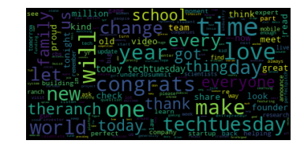

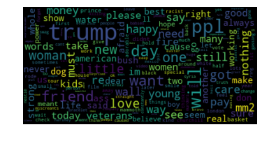

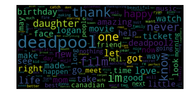

```python
# Generate celebrity word clouds
for i in range(len(celeb_strings)):
    generate_wordclouds(celeb_strings[i])
```

Create word clouds for politicians. Obama talks about obamacare (unsurprising), Theresa May writes prime minister often, and Malcolm Turnbull (Australian prime minister) mentions Australia a lot.

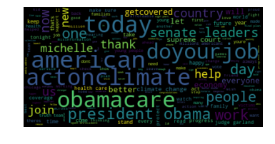

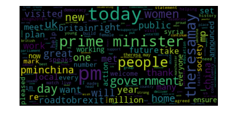

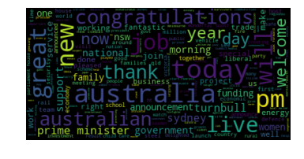

```python
# Generate politician word clouds
for i in range(len(politician_strings)):
    generate_wordclouds(politician_strings[i])
```

Trump's word cloud. The words Trump, great, and border are quite prominent.

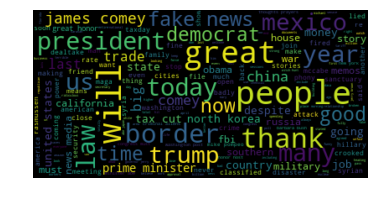

```python
# generate Trump word cloud
generate_wordclouds(Trump_string)
```

# Sentiment Analysis

Now that the cleaning and qualitative exploration is through, TextBlob will assign a numerical score measuring the sentiment of all the Tweets collected for a user.

```python
def sentiment(strings):
    sentiments = []
    for t in strings:
        tweet = TextBlob(t)
        sentiments = np.append(sentiments, tweet.sentiment.polarity)
    return sentiments
```

```python
politician_sentiment = sentiment(politician_strings)
celeb_sentiment = sentiment(celeb_strings)

print("Politician Scores")

for i in range(len(politician_sentiment)):
    print(politician_user[i], 'has sentiment score:', round(politician_sentiment[i], 3))

print("")
print("Celebrity Scores")

for i in range(len(celeb_sentiment)):
    print(celebrity_user[i], 'has sentiment score:', round(celeb_sentiment[i], 3))
```

```
Politician Scores
BarackObama has sentiment score: 0.206
theresa_may has sentiment score: 0.223
TurnbullMalcolm has sentiment score: 0.288

Celebrity Scores
aplusk has sentiment score: 0.233
cher has sentiment score: 0.152
VancityReynolds has sentiment score: 0.207
```

Perform sentiment analysis on Trump's Tweets

```python
tweets = TextBlob(Trump_string)
Trump_sentiment = tweets.sentiment.polarity
print("Trump's sentiment score:", round(Trump_sentiment, 3))
```

```
Trump's sentiment score: 0.089
```

### Visualize

Now that we have the sentiment scores, it is still hard to visualize what these look like relative to each other. Below the politician's sentiments are to the left, celebrities to the right. Trump's sentiment score has been superimposed on each graph as a red horizontal line.

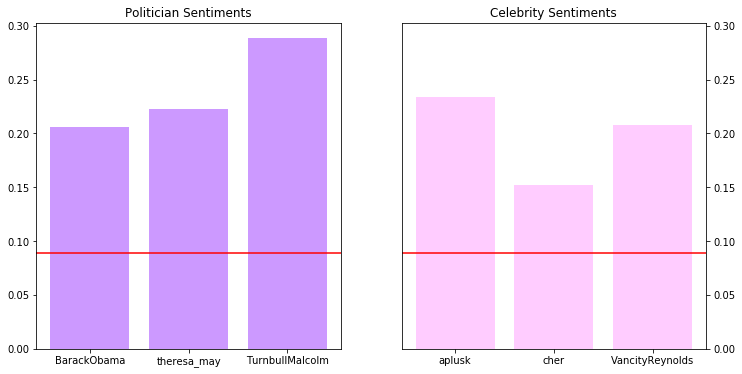

```python
fig = plt.figure(figsize=(12, 6))

ax = plt.subplot(121)
ax.bar(range(len(politician_user)),politician_sentiment, tick_label = politician_user, color = "#cc99ff")
plt.axhline(Trump_sentiment, color = 'r')
plt.title("Politician Sentiments")

ax2 = plt.subplot(122, sharey = ax)
ax2.bar(range(len(celebrity_user)), celeb_sentiment, tick_label = celebrity_user, color = "#ffccff")
plt.axhline(Trump_sentiment, color = 'r')
ax2.yaxis.tick_right()
plt.title("Celebrity Sentiments")
```

It seems from these plots that Trump's sentiment isn't quite like that of either group. It does seem to have the closest value to Cher's Tweets. This connection is intersting as back in the word cloud section, we saw that one of Cher's most commonly used words was Trump!

Given that visually it's not very striking that Trump's sentiment is very like or dislike either group, let's do a numerican comparison as well.

Take the difference between Trump's sentiment and each politician or celebrity, square this value (no negatives) and sum them together. This is one way to measure the sentiment difference between Trump and a group.

```python
political_Trump = np.sum(((politician_sentiment - Trump_sentiment)**2))
```

```python
celeb_Trump = np.sum((celeb_sentiment - Trump_sentiment)**2)
```

```python
print("The sentiment difference between the politicians and Trump is:", political_Trump)
```

```
The sentiment difference between the politicians and Trump is: 0.0709504392821
```

```python
print("The sentiment difference between the celebrities and Trump is:", celeb_Trump)
```

```
The sentiment difference between the celebrities and Trump is: 0.0385423728625
```

### Plot the sentiment differences

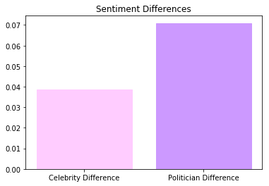

```python
differences = plt.bar([1,2], [celeb_Trump, political_Trump],
                      tick_label = ['Celebrity Difference', 'Politician Difference'])
differences[0].set_color("#ffccff")
differences[1].set_color("#cc99ff")
plt.title("Sentiment Differences")
```

# Conclusion

It seems that sentiment-wise, Trump's Tweets aren't quite like those of either group. From the plot with all sentiments it seemed that Trump's score was exceptionally low coompared to other users selected. This difference may be due to the celebrities and politicians chosen, but may be part of a larger trend. It cannot be determined from this sample. A larger and more diverse sampling may help make this distinction more clear. Even with this small sample size the sentiment differences reveal a smaller difference between Trump and the celebrities chosen. These scores are not significantly different though and this is not a strong connection. One of the most interesting findings was that Cher's Tweets and Trump's had the most similar sentiment score, and Cher writes of Trump often in her Tweets.

Run it again and maybe get different results if a user has Tweeted since the last time it was run! Add different users! More?